# Data Handling: Import, Cleaning and Visualisation

Lecture 11:  
Wrap up

Dr. Aurélien Sallin

2025-12-18

## Plan for today

1. Recap
2. Wrap up course and group project
3. Exam Info
4. Suggested Improvements
5. Concluding remarks
6. Q&A

# Recap: Data Visualization and Text Data

## Data visualization

Two ways: display data through **tables** or **graphs**. Depends on the purpose.

Use `ggplot()` and the grammar of graphics to produce effective graphs.

## A Design Problem (self-study)

What is wrong with the graph below? Create your own version of the graph.

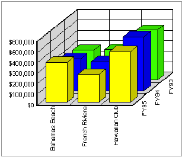

Source: [perceptual edge](https://perceptualedge.com/example3.php)

## A first solution: comparative performance

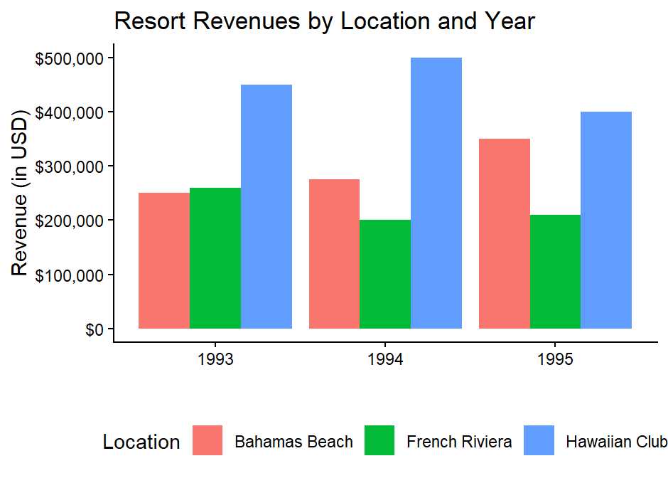

```r
ggplot(dataChallenge, aes(x = Fiscal_Year, y = Revenue, fill = Location)) +
  geom_bar(stat = "identity", position = position_dodge()) +
  labs(
    title = "Resort Revenues by Location and Year",
    x = "Year",
    y = "Revenue (in USD)"
  ) +
  scale_y_continuous(labels = scales::dollar) +
  scale_x_discrete(labels = c("1993", "1994", "1995")) +
  theme_classic() +
  theme(legend.position = "bottom")
```

## A second solution: change of revenue over time

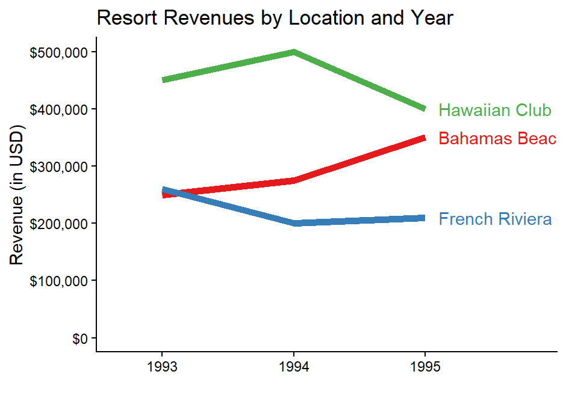

- This design makes it easy to see how revenue has changed from year to year at each of these resorts.

```r
ggplot(dataChallenge, aes(x = Fiscal_Year, y = Revenue, color = Location,
                          group = Location)) +
  geom_line(size = 2) +
  geom_text(data = dataChallenge[dataChallenge$Fiscal_Year == "FY95", ],
            aes(label = Location), hjust = 0, nudge_x = 0.1, nudge_y = 0) +
  labs(
    title = "Resort Revenues by Location and Year",
    x = "",
    y = "Revenue (in USD)"
  ) +
  scale_y_continuous(labels = scales::dollar, limits = c(0, 500000)) +
  scale_x_discrete(labels = c("1993", "1994", "1995"),
                   expand = expansion(add = c(0.5, 1))) +
  theme_classic() +
  theme(legend.position = "none")  +
  scale_color_brewer(palette = "Set1")
```

## Tufte’s principles of data visualization

#### Minimize the **Lie Factor**

$\frac{\text{size of effect shown in graphic}}{\text{size of effect in data}}$

#### Maximize the **Data-ink Ratio**

$\frac{\text{ink used for data points}}{\text{total ink used to print the graphic}}$

#### Maximize the **Data density**

$\frac{\text{number of entries in data matrix}}{\text{area of data graphic}}$

## Minimize the **Lie Factor**

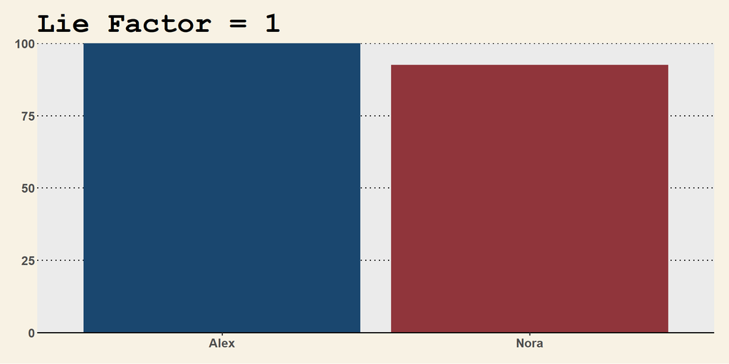

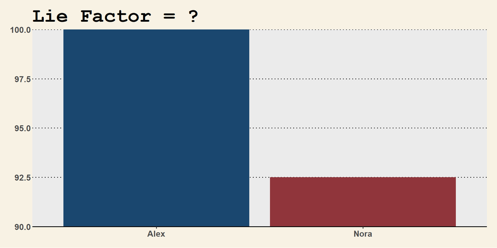

**Lie Factor**

The Lie Factor is 3.7 ((10/2.5)/(100/92.5))

Do you recognize the theme?

## Maximize the **Data-ink Ratio**

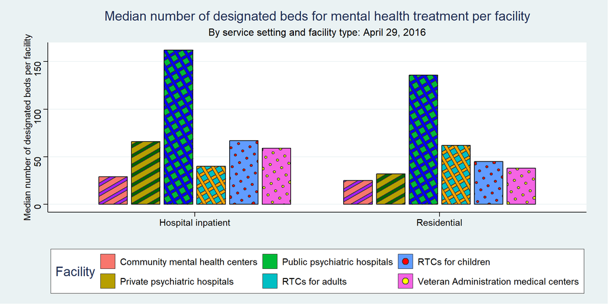

**Show code for the graphs**

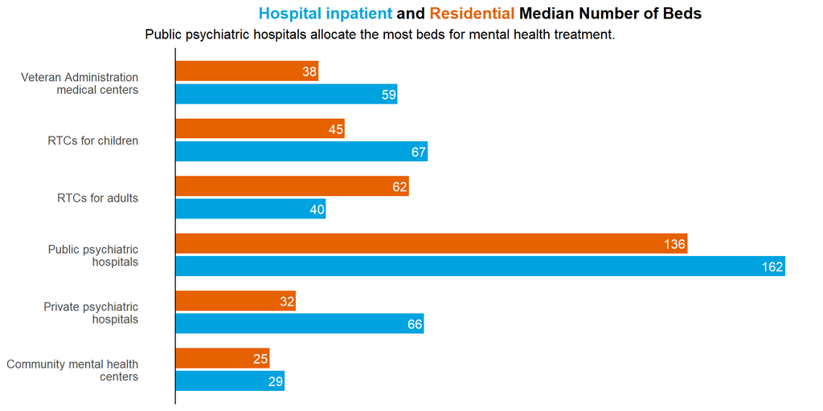

```r
ggplot(data, aes(x = Setting, y = Beds, pattern = Facility, fill = Facility, group = Facility)) +
  geom_col_pattern(
    aes(pattern = Facility, fill = Facility, pattern_fill = Facility),
    colour = 'black',
        width = 0.7,
    position = position_dodge(width = 0.8),
    pattern_density          = 0.35) +
    scale_pattern_fill_manual(
      values = c("Public psychiatric hospitals"='blue',
                 "RTCs for children"='red',
                 "Veteran Administration medical centers"='yellow',
                 "Private psychiatric hospitals"='darkgreen',
                 "RTCs for adults" = 'orange',
                 "Community mental health centers" = 'purple')) +
  labs(title = "Median number of designated beds for mental health treatment per facility",
       subtitle = "By service setting and facility type: April 29, 2016",
       x = "",
       y = "Median number of designated beds per facility") +
  theme_stata(base_size = 12) +
  theme(legend.position = "bottom",
        axis.text.x = element_text(angle = 0, hjust = 0.5))
```

**Show code for the graphs**

```r
data$Facility <- str_wrap(data$Facility, width = 25)

ggplot(data, aes(x = Beds, y = Facility, fill = Setting)) +
  geom_col(position = position_dodge(width = 0.8), width = 0.7) +
   geom_text(aes(label = Beds),
            position = position_dodge(width = 0.8),  # Align with bars
            hjust = 1.1,  # Align left/right
            color = "white", size = 4) +  # Text color and sizesst color and size of the text
  scale_fill_manual(values = c("Hospital inpatient" = "#00A3E0",  # Cyan for hospital inpatient
                               "Residential" = "#E66100")) +     # Dark blue for residential
  labs(
    title = "<span style='color:#00A3E0;'>Hospital inpatient</span> and <span style='color:#E66100;'>Residential</span> Median Number of Beds",
    subtitle = "Public psychiatric hospitals allocate the most beds for mental health treatment.",
    x = NULL,
    y = NULL
  ) +
  theme_minimal(base_size = 12) +
  theme(
    axis.text.x = element_blank(),  # Remove x-axis labels
    axis.ticks.x = element_blank(),
    axis.text.y = element_text(size = 10),
    legend.position = "none",
    plot.title = element_markdown(hjust = 0.5, size = 14, face = "bold"),  # Title with colored text
    panel.grid = element_blank()  # Remove grid lines
  ) +
  geom_vline(xintercept = 0, color = "black", linetype = "solid", size = 0.5)
```

## Maximize data density

[figure not shown]

Source: [data-viz-workshop-2021](https://badriadhikari.github.io/data-viz-workshop-2021/Tufte/Chapter_8/)

#### 4 data points: 0.39, 0.56, 0.3, 2000 😱

# Exam

## 📢 Decentral exam and LockDown browser

#### Exam for exchange students

- 18.12.2025 at 16:15.
- **BYO + cord🔌 + 🖱️**

#### Lockdown browser

- Exam and LockDown Browser: check Sharepoint on StudentWeb and test on Canvas.

## Exam questions

- True/False questions, multiple-choice questions, and multiple-correct options. These are designed to test your understanding of the material.
- ❗Exactly same style and structure as quizzes and mock exam❗
- We do not invent wrong function parameters or misspell function names etc to mislead you!
- ‘Passive’ knowledge of key R syntax and most important functions of core lecture contents are important!
- Work step-by-step through the code example. What happens in each parenthesis, on each line?
- From the inner part to the outer part, from top to bottom.
- Use pencil/paper to keep track of values, data structures (how does a data-frame look like?), classes.
- Importantly, if a code-example question refers to specific functions, you can always assume that the corresponding package is also loaded.

## Questions on the examination?

# Wrap up

## At the end of the course, you will be able to…

- **Understand the tools you need when working with data**
- **Work independently with data**
- **Ask the right questions to a dataset**
- **Learn to communicate about data**

## My commitment to these goals and to your learning process

- **Transferrable skills**
- **Hands-on approach**
- **Emphasis on real-world relevance**  
  (caveat: this course is mandatory for Econ students, I have limited freedom in the syllabus)
- **As much fun as possible (as coding can be fun…😎)**

[figure not shown]

## Wrap up: Conceptual part

- **Understand the very basics of how computers process data.**
  - Computers store data as bits (Bits → Bytes → Encoded Text)
  - Text encodes meaning using encodings and standards
  - Files encode structure (→ Structured Files with special characters)
    - CSV: two-dimensional/table-like structure
    - JSON/XML: hierarchical data (high-dimensional)
  - R *parses* structure into RAM. (→ R Parsing → R Data Structures)
- **Deal with data from all possible sources.**
  - APIs, Webscrapers, JSON, etc.

## Wrap up: Applied part

- Import data into R. What to do if the parsing fails?
- Clean/prepare data in R. Aim: tidy data set (rows:observations, columns:variables).
- Filter, select, mutate, summarise.
- Compute basic summary statistics using group_by and summarise.
- Visualize raw data and basic statistics.

## Wrap up: Group Project

#### First of all…

- I am **impressed** by your performance, interest, and dedication.
- The project was challenging, and part of the project was navigating **frustration** and **uncertainty**.
- This is **close to a real job or research project**, where there is often more than one correct answer.
- With LLMs, navigating the full data handling pipeline is becoming a **basic skill** rather than an advanced one.

#### From my side

- First year, first try, first experience.
- I had fun. I hope you did too.

###### Congrats!

## Wrap up: Group Project

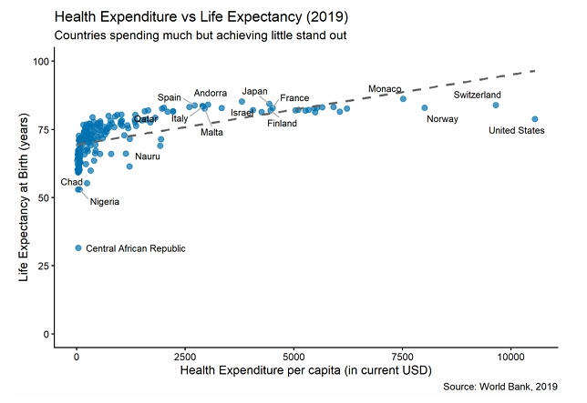

## Wrap up: Group Project

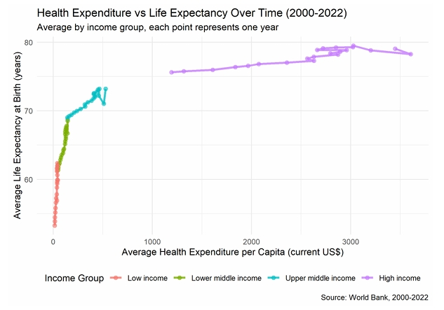

## Wrap up: Group Project

[figure not shown]

## Wrap up

- You went from first steps into programming to managing an entire data science pipeline 💪
- You can now work with APIs, clean data, and communicate results through visualisations
- You had first examples on how this is applied in the finance industry

# Course Evaluation and Feedback

## Course evaluation

- This course was designed to be challenging and close to real research and work settings. Your feedback helps improve it for the next cohort.
- This was the first year in this format. Some things worked very well, others can be improved.

## Evaluation link

[figure not shown]

[Link 🔗](https://go.blueja.io/irtnIL3QI0OgSPRQeOEAVw)

# Final Remarks

## Final Remarks

#### Let’s keep in touch!

- LinkedIn 📲
- Join the **`R` User Group in Zürich**!
  - Next event: **29.01.2026, 18:00 - 21:30** at the ETH (DevOps for Data Science at KOF Institute).
  - Apéro + networking 🍕🍺
  - Free Registration on Meetup
  - Presentations from R-Users in the industry and in academia. Past events at Datahouse, SNB, Helsana, Swiss, etc.

## Final Remarks

- I had a lot of fun 🙏
- All the best for your exams! 👍
- See you very soon 👀🔜

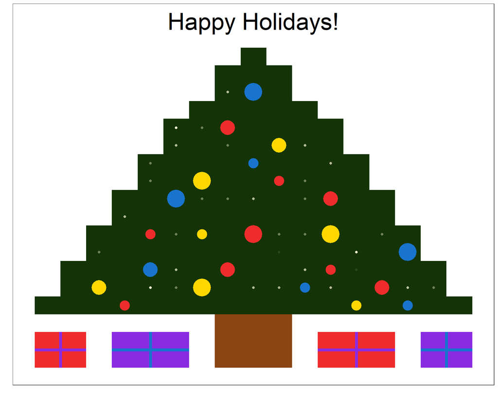

Made with `ggplot`. Source: [‘A very ggplot2 Christmas’](https://t-redactyl.io/blog/2016/12/a-very-ggplot2-christmas.html)